# Exploración de Datos: Anomalías, visualización y transformaciones

Maria L Zamora y Ali Limon

Agosto 30, 2018

# 1. Normalización

Una de las herramientas principales durante la creación de modelos es el trabajo de preparación de los datos, hasta ahora hemos visto como descargarlos, como conseguir información nueva y unirla, como obtener estadísticos descriptivos, como filtrar y agrupar, como crear distribuciones y usar estructuras de datos que simplifican todos estos procesos (e.g. dataframes).

Ya hemos platicado acerca del proceso de muestras y algunos aspectos que debemos evitar durante la extracción: Bias y Leakage. Puede ser que se haya analizado lo suficiente el diseño de extracción para evitar contar con estos dos aspectos. Sin embargo, en caso de que no sepamos mucho sobre el diseño, un siguiente punto a considerar es el tema de normalización para cuando se presenten muestras sesgadas:

Para que nos sirve la normalización? Cada vez que trabajamos con datos para evaluar compañías o instrumentos financieros, debemos analizar la escala de las variables que estamos usando. Algunas pueden hacer referencia a aspectos monetarios de alguna compania, mientras que otras pueden representar en porcentaje el valor de los retornos. La mayoría de los modelos en Ciencia de Datos y Machine Learning hacen comparaciones generales de los datos, por lo cual esperaríamos que las diferencias en escalas no fueran un problema. Para ello vamos a mencionar dos ejemplos de normalización:

- Estandarización: Centrar los datos (restando la media) y escalar (dividiendo entre desviación estándar). Este es el mas común.
- Escalar en un rango: Podemos reasignar valoresnúmeros entre 0 y 1 (0 será el valorproporción mínimo y 1 el valor máximo de cada columna, reasignando todos los números intermedios en esta proporción).

# 2. Anomalías en los datos

Una vez que tenemos preparados los datos y empezamos a trabajar en los estadísticos descriptivos, debemos ver con mas detalle las implicaciones de estos resultados. No solo se trata de hacer cálculos con la mejor predicción, se trata de usar modelos que vayan de acuerdo con la lógica del problema. Para esto, al obtener los estadísticos descriptivos e incluso después de la normalización, puede que nos demos cuenta de la existencia de nuevos problemas como los siguientes:

- Un exceso de valores inusuales y con alta influencia en la muestra
- Un exceso de características/variables a evaluar en comparación con el tamaño de muestra - High dimensionality

### 2.1 Diagnósticos - Distribuciones y relaciones

Para referirnos al diagnostico de anomalías en una muestra de tamaño chico, vamos a utilizar la misma lista de compañías globales, seleccionando aquellas empresas que cotizan en bolsa y están localizadas en Mexico. En este sentido estamos trabajando con aspectos de los renglones de nuestro dataset (registros).

- La primera parte del código corresponde a leer, describir y filtrar el dataframe.

```r
##### Read the files
globalCompanies <- read.csv("outliers_data/globalCompanies_sandp.csv")

##### Take a look to the size and columns
nrow(globalCompanies)
```

```
## [1] 55076
```

```r
colnames(globalCompanies)
```

```
##  [1] "Ticker"                "Address"
##  [3] "City"                  "Country"
##  [5] "Industry"              "LongBusinessSummary"
##  [7] "Sector"                "State"
##  [9] "Website"               "fullTimeEmployee"
## [11] "zip"                   "currentPrice"
## [13] "ebitda"                "totalRevenue"
## [15] "totalDebt"             "sharesOutstanding"
## [17] "fiveYearAverageReturn" "SandP52WeekChange"
## [19] "quoteYield"            "quote52WeekChange"
## [21] "Security"
```

```r
##### Summary
sapply(globalCompanies,class)
```

```
##                Ticker               Address                  City
##              "factor"              "factor"              "factor"
##               Country              Industry   LongBusinessSummary
##              "factor"              "factor"              "factor"
##                Sector                 State               Website
##              "factor"              "factor"              "factor"
##      fullTimeEmployee                   zip          currentPrice
##             "integer"             "integer"             "numeric"
##                ebitda          totalRevenue             totalDebt
##             "numeric"             "numeric"             "numeric"
##     sharesOutstanding fiveYearAverageReturn     SandP52WeekChange
##             "numeric"              "factor"             "numeric"
##            quoteYield     quote52WeekChange              Security
##              "factor"             "numeric"              "factor"
```

```r
table(sapply(globalCompanies,class))
```

```
##
##  factor integer numeric
##      12       2       7
```

```r
summary(globalCompanies$Country)[0:13]
```

```
##                            Anguilla Antigua & Barbuda         Argentina
##             32050                 2                 1                90
##         Australia           Austria        Azerbaijan           Bahamas
##              1322                91                 1                 6
##        Bangladesh          Barbados           Belgium            Belize
##                 3                 2               215                 3
##           Bermuda
##               110
```

```r
##### Filtre
suppressMessages(library(dplyr))
mexComp <- filter(globalCompanies, Country=="Mexico")
```

- Ahora, podemos agregar nuevas columnas con métricas de evaluación de la compañías y eliminar casos incompletos.

```r
### Capitalización de mercado
mexComp$marketCap <- mexComp$currentPrice * mexComp$sharesOutstanding
### Apalancamiento o Leverage : Borrowed money (debt) to generate returns on investments
### Debt-to-EBITDA Ratio
mexComp$leverageEbitda <- mexComp$totalDebt / mexComp$ebitda
```

```r
##### Filter rows with missings
mexComp <- mexComp[complete.cases(mexComp), ]
nrow(mexComp)
```

```
## [1] 125
```

- Para iniciar el análisis de anomalías a graficar una de las columnas que acabamos de crear

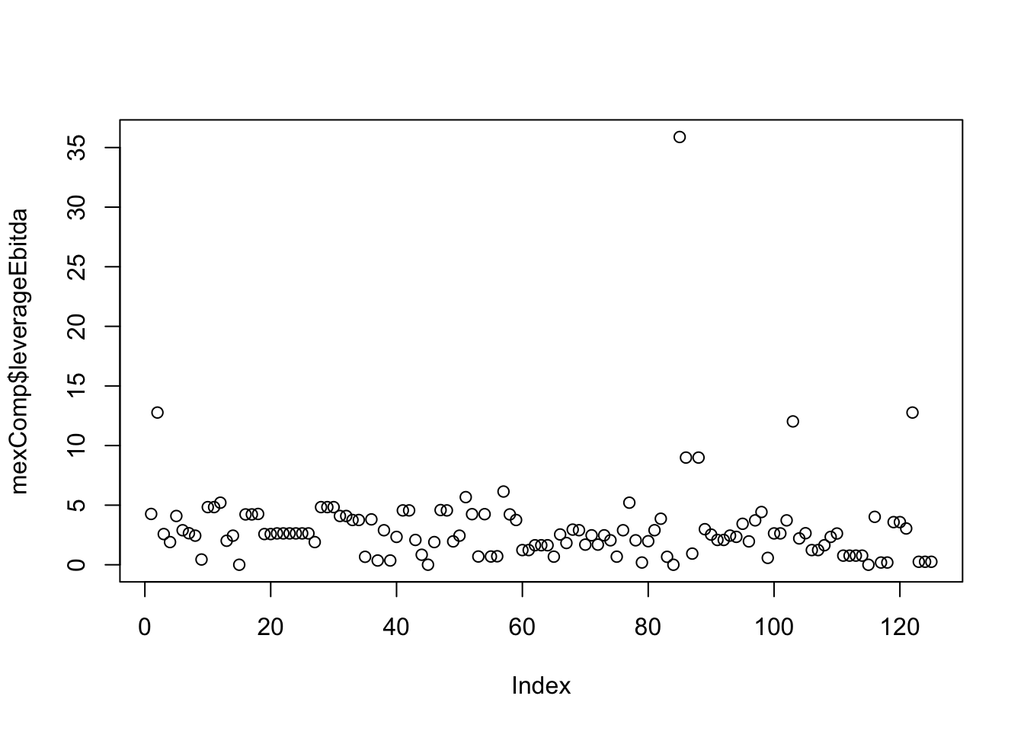

```r
plot(mexComp$leverageEbitda)
```

```r
#identify(mexComp$leverageEbitda)
```

```r
mexComp[85,]
```

```
##     Ticker                           Address        City Country
## 102 ICS1.F Boulevard Manuel Avila Camacho 36 Mexico City  Mexico
##                       Industry
## 102 Engineering & Construction
##                                                                                                                                                                                                                                                                                                          …
## 102 Empresas ICA, S.A.B. de C.V., through its subsidiaries, engages in construction and related activities for the public and private sectors. The company operates through five segments: Civil Construction, Industrial Construction, Airports, Concessions, and Corporate and Other. The Civil Constru…
##          Sector State               Website fullTimeEmployee  zip
## 102 Industrials    DF http://www.ica.com.mx             7286 7286
##     currentPrice   ebitda totalRevenue  totalDebt sharesOutstanding
## 102        0.017 91089352   1079300736 3268675840         611030016
##     fiveYearAverageReturn SandP52WeekChange quoteYield quote52WeekChange
## 102                    {}         0.1697928         {}        -0.9205607
##     Security marketCap leverageEbitda
## 102           10387510       35.88428
```

- Ahora vamos a utilizar algunas herramientas de visualización, para esto vamos a tomar la variable “fullTimeEmployee” donde podremos ver que los valores reales de esta columna no nos permiten ver correctamente la distribución. Para resolver esto hacemos una transformación con la función de logaritmo. Con esto vamos a seguir conservando la distribución y podemos volver a los valores originales con la función inversa (exponencial). Los valores de tipo monetario son los que comúnmente requieren de este proceso, particularmente porque suelen ser procesos mutiplicativos (cuyos incrementos se dan en porcentajes y no en diferencias de valor).

```r
###############  Histograms and log values
summary(mexComp$fullTimeEmployee)
```

```
##    Min. 1st Qu.  Median    Mean 3rd Qu.    Max.
##      63    2599    7069   42800   60500  303300
```

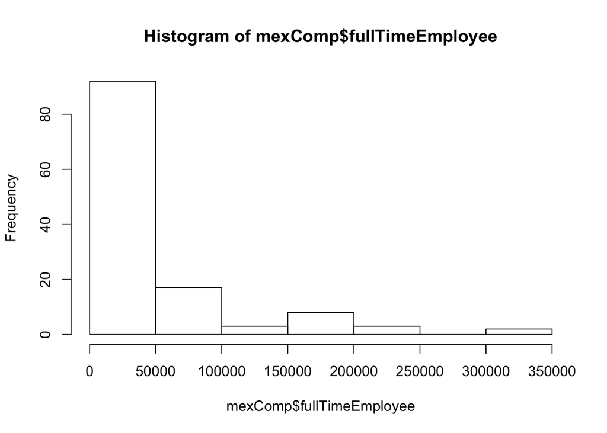

```r
hist( mexComp$fullTimeEmployee )
```

```r
summary(mexComp$fullTimeEmployee )
```

```
##    Min. 1st Qu.  Median    Mean 3rd Qu.    Max.
##      63    2599    7069   42800   60500  303300
```

```r
summary( log(mexComp$fullTimeEmployee ) )
```

```
##    Min. 1st Qu.  Median    Mean 3rd Qu.    Max.
##   4.143   7.863   8.863   9.222  11.010  12.620
```

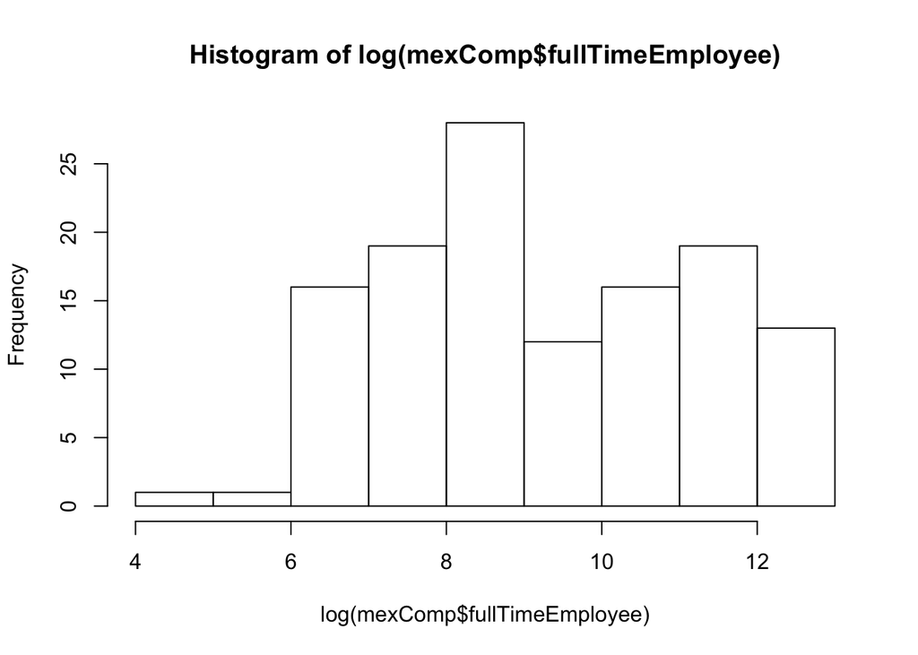

```r
hist( log(mexComp$fullTimeEmployee ) )
```

```r
summary(log(mexComp$fullTimeEmployee ) )
```

```
##    Min. 1st Qu.  Median    Mean 3rd Qu.    Max.
##   4.143   7.863   8.863   9.222  11.010  12.620
```

- En la siguiente gráfica podemos ver la comparación del resto de las variables que usaremos, en ambas escalas.

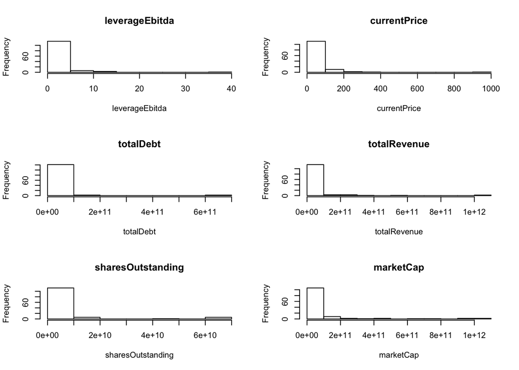

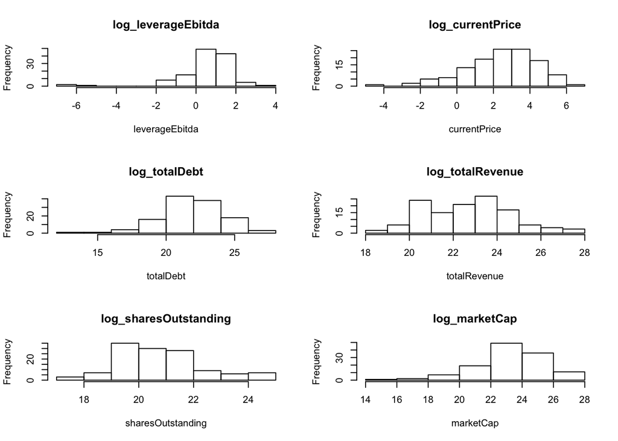

- De este modo vamos a incluir en nuestro dataframe todas estas variables pero aplicando la transformación.

```r
mexComp$log_fullTimeEmployee <- log(mexComp$fullTimeEmployee)
mexComp$log_currentPrice <- log(mexComp$currentPrice)
mexComp$log_totalDebt <- log(mexComp$totalDebt)
mexComp$log_totalRevenue <- log(mexComp$totalRevenue)
mexComp$log_sharesOutstanding <- log(mexComp$sharesOutstanding)
mexComp$log_marketCap <- log(mexComp$marketCap)
mexComp$log_leverageEbitda <- log(mexComp$leverageEbitda)

colnames(mexComp)
```

```
##  [1] "Ticker"                "Address"
##  [3] "City"                  "Country"
##  [5] "Industry"              "LongBusinessSummary"
##  [7] "Sector"                "State"
##  [9] "Website"               "fullTimeEmployee"
## [11] "zip"                   "currentPrice"
## [13] "ebitda"                "totalRevenue"
## [15] "totalDebt"             "sharesOutstanding"
## [17] "fiveYearAverageReturn" "SandP52WeekChange"
## [19] "quoteYield"            "quote52WeekChange"
## [21] "Security"              "marketCap"
## [23] "leverageEbitda"        "log_fullTimeEmployee"
## [25] "log_currentPrice"      "log_totalDebt"
## [27] "log_totalRevenue"      "log_sharesOutstanding"
## [29] "log_marketCap"         "log_leverageEbitda"
```

- Otra evaluación que se puede hacer al respecto, para entender mas a fondo la distribución, es la gráfica de cuantiles con un “BoxPlot”. Es frecuente usarla cuando existe una variable categórica de por medio. R tiene por default la gráfica de “BoxPlot”, sin mebargo, preferimos el uso de la librería ggplot que contiene la gráfica “geom_boxplot”. Como podrán observar, se ve muy clara la diferencia con y sin logaritmos.

```r
############### Box plots / whisker diagram per sector
##### Group by
mexIndustry <- group_by(mexComp, Sector)
mexIndustry <- summarize(mexIndustry, count = n(), marketCap_average= mean(marketCap, na.rm = TRUE)/1000000000, totalRevenue_average= mean(totalRevenue, na.rm = TRUE)/1000000000, totalfullTimeEmployee_average= mean(fullTimeEmployee, na.rm = TRUE) )
arrange(mexIndustry, desc(marketCap_average))
```

```
## # A tibble: 15 × 5
##                    Sector count marketCap_average totalRevenue_average
##                    <fctr> <int>             <dbl>                <dbl>
## 1  Communication Services     9       361.8339860            33.995047
## 2              Technology     3       241.7973298           679.126381
## 3      Consumer Defensive    19       132.3474483            55.970796
## 4           Conglomerates     1       122.0809100           322.095612
## 5        Industrial Goods     4        87.1634610            72.180084
## 6         Basic Materials    21        80.7534280            13.439835
## 7                Services     7        75.5102491            39.041849
## 8          Consumer Goods     7        60.1741696           109.444579
## 9               Financial     2        58.0636016             9.703844
## 10            Industrials    27        19.4506355             6.431480
## 11     Financial Services     3        14.3756096            11.419517
## 12      Consumer Cyclical    17        12.4661877             5.108831
## 13             Healthcare     2         8.1710999             6.253608
## 14            Real Estate     2         7.8203527             6.957723
## 15                            1         0.2928586             1.195884
## # ... with 1 more variables: totalfullTimeEmployee_average <dbl>
```

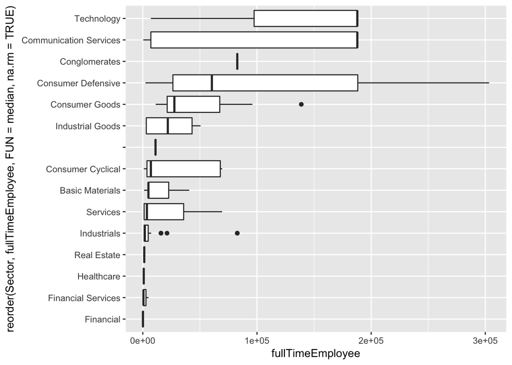

```r
#####   Skewed or symmetric: Points more than 1.5 times above 3rd quantile  -> outliers
par(mfrow=c(1,1))


##### Ggplot library functions
suppressMessages(library(ggplot2))
ggplot(data = mexComp) +
  geom_boxplot(
    mapping = aes(
      x = reorder(Sector, fullTimeEmployee, FUN = median, na.rm=TRUE), y=fullTimeEmployee
    ) ) +
  coord_flip()
```

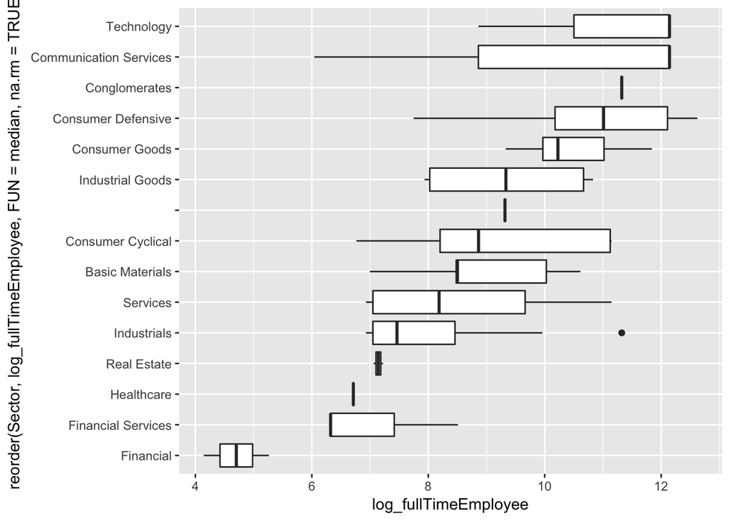

```r
ggplot(data = mexComp) +
  geom_boxplot(
    mapping = aes(
      x = reorder(Sector, log_fullTimeEmployee, FUN = median, na.rm=TRUE), y=log_fullTimeEmployee
    ) ) +
  coord_flip()
```

- Finalmente, una herramienta muy util que nos acerca a entender la interacción entre variables (relación lineal, por ejemplo) es la gráfica de pares para variables numéricas / enteros.

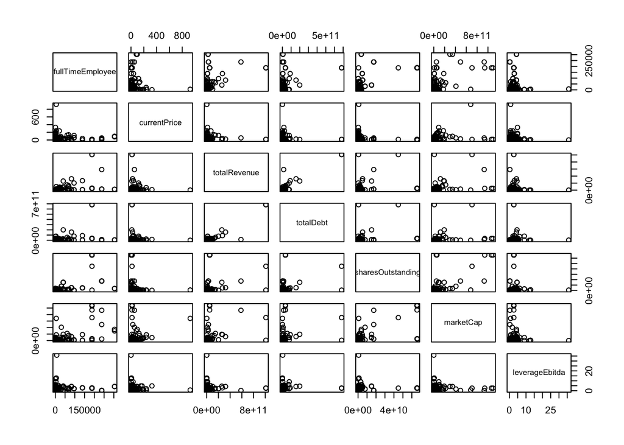

```r
############### Pairs of numeric variables
varMexComp <- c('fullTimeEmployee','currentPrice','totalRevenue','totalDebt','sharesOutstanding','marketCap','leverageEbitda')
pairs(mexComp[varMexComp])
```

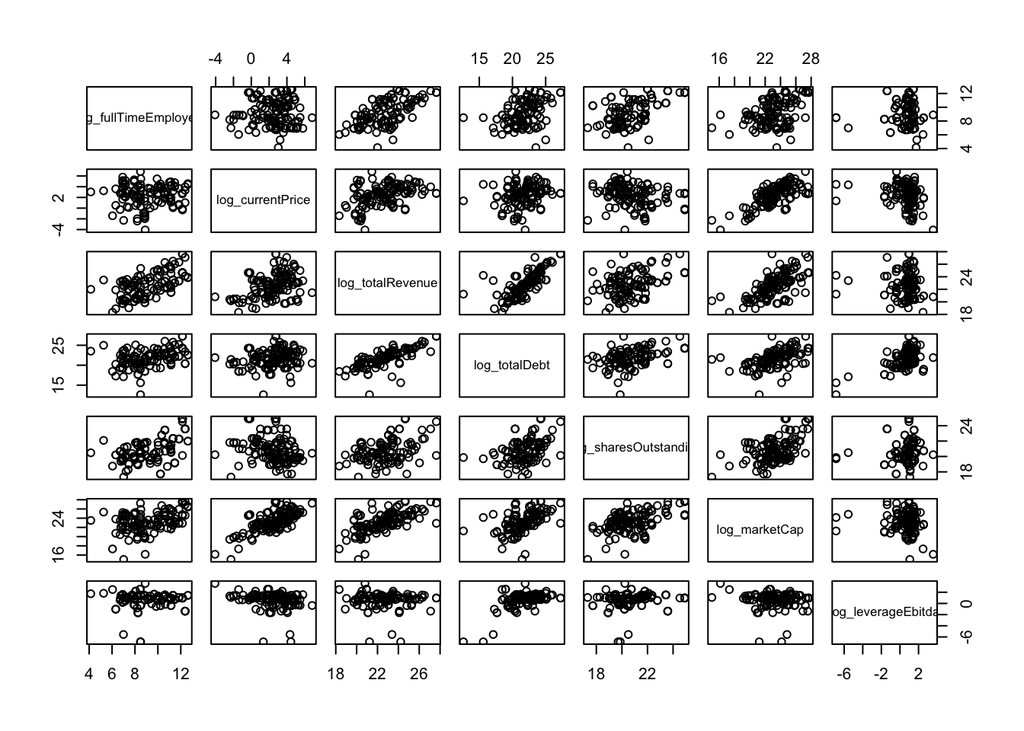

```r
mexCompNumeric <- mexComp[varMexComp]

log_varMexComp <- c('log_fullTimeEmployee','log_currentPrice','log_totalRevenue','log_totalDebt','log_sharesOutstanding','log_marketCap','log_leverageEbitda')
pairs(mexComp[log_varMexComp])
```

```r
mexCompLogNumeric <- mexComp[log_varMexComp]

##### avoid +/- Inf
mexCompLogNumeric  <- mexCompLogNumeric [is.finite(rowSums(mexCompLogNumeric )),]
nrow(mexCompLogNumeric )
```

```
## [1] 124
```

Todos estos análisis exploratorios nos llevan a pensar en los registros que pueden estar contaminando nuestro modelo, o en algunos casos que pueden ser señales importantes de otro patrón en la muestra. Existen 3 tipos de datos a evaluar en este sentido, particularmente para referirnos a relaciones entre los datos:

1. *Outliers*: cases far off.
2. *Leverage points*: strong effect (R2, t–statistics, and the F–statistic) - change of slope.
3. *Influential points*: large change.

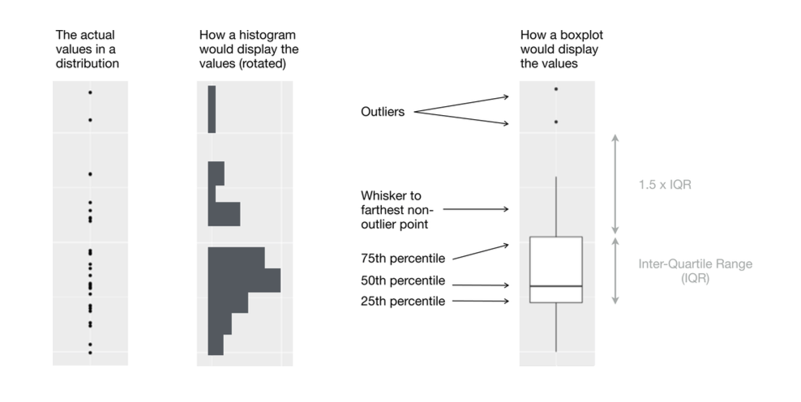

*Source: R for data science[^1]*

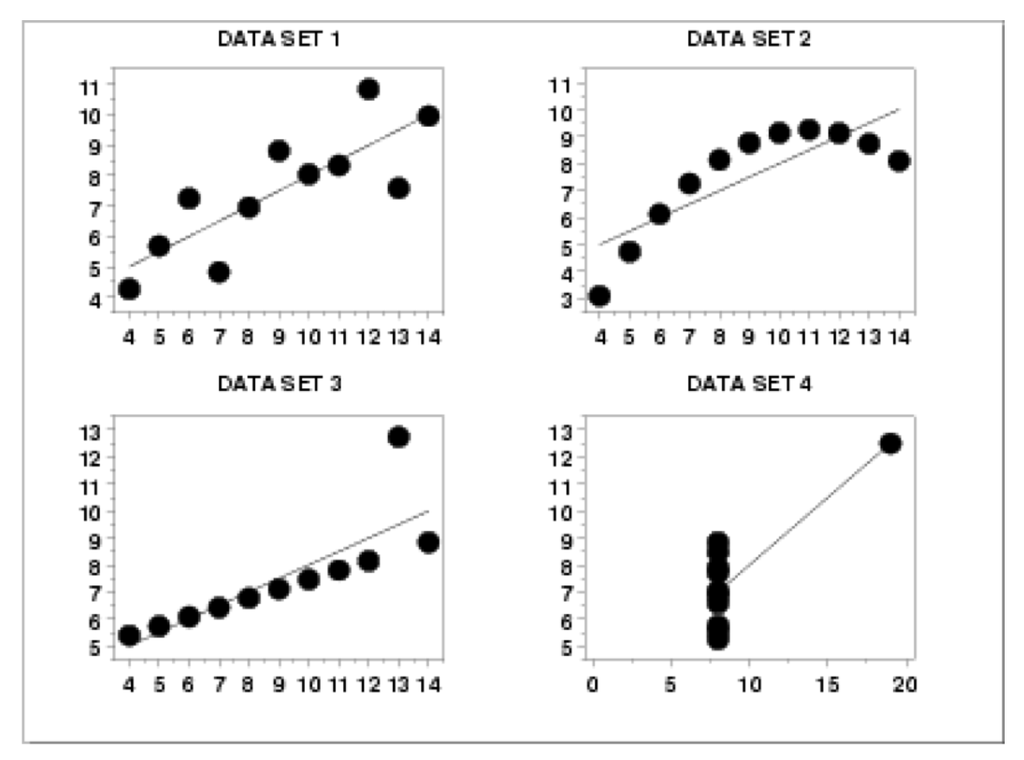

No necesariamente los vamos a encontrar todos durante esta etapa, es probable que encontremos algunos una vez terminado el modelo (como en el siguiente ejemplo de un modelo lineal), pero una vez que los identifiquemos es necesario entender sus causas e implicaciones.

- Ahora vamos a hacer referencia a este tipo de anomalías con ayuda de un modacciónelo lineal, en este caso estamos haciendo una relación muy sencilla entre el valor del precio actual de la acción de la compañía (currentPrice) y una combinación lineal de la cantidad de empleados (fullTimeEmployee) y de ingresos (totalRevenue). Mas adelante durante el curso hablaremos mas al respecto de las relaciones que pueden tener los datos, por ahora basta con entender que esta primera aproximación nos permite usar las siguientes medidas para identificar valores no usuales[^2].

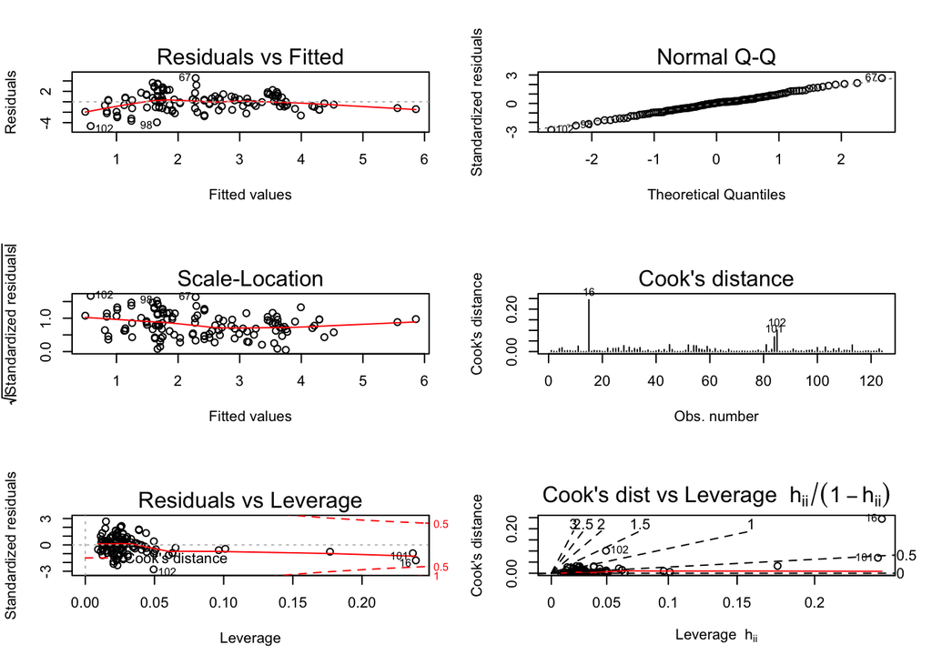

```r
#mexComp <- mexComp[-115,]

############### Diagnostics using linear models
reg <- lm(log_currentPrice~log_totalRevenue+log_fullTimeEmployee+log_leverageEbitda, mexCompLogNumeric )
par(mfrow=c(3,2))
plot(reg, which=1:2)
plot(reg, which=3:4)
plot(reg, which=5:6)
```

- El siguiente código en R nos permite encontrar dichos puntos específicos para poder evaluar sus causas y removerlos para ver el efecto que tienen en el modelo.

```r
mexComp[102,]
```

```
##     Ticker                   Address                City Country  Industry
## 120  MXCHF R\\xedo San Javier No. 10 Tlalnepantla de Baz  Mexico Chemicals
##                                                                                                                                                                                                                                                                                                          …
## 120 Mexichem, S.A.B. de C.V. manufactures and markets chemicals and petrochemical products, and plastic pipes and fittings worldwide. The company operates through Vinyl, Energy, Fluor, and Fluent segments. The company offers base chemicals, specialty resins, PVC resins, compounds, PA and plastici…
##              Sector State                 Website fullTimeEmployee   zip
## 120 Basic Materials    EM http://www.mexichem.com            22665 22665
##     currentPrice     ebitda totalRevenue  totalDebt sharesOutstanding
## 120       3.3951 1222553856   6189423104 4553696256        2098060032
##     fiveYearAverageReturn SandP52WeekChange quoteYield quote52WeekChange
## 120                    {}         0.1697928         {}         0.2039362
##     Security  marketCap leverageEbitda log_fullTimeEmployee
## 120          7123123615       3.724741             10.02858
##     log_currentPrice log_totalDebt log_totalRevenue log_sharesOutstanding
## 120         1.222333      22.23921         22.54611              21.46428
##     log_marketCap log_leverageEbitda
## 120      22.68661           1.314997
```

```r
mexComp[16,]
```

```
##      Ticker                                         Address
## 17 ALFAA.MX Avenida G\\xf3mez Mor\\xedn Avenue Sur No. 1111
##                          City Country      Industry
## 17 San Pedro Garza Garc\\xeda  Mexico Conglomerates
##                                                                                                                                                                                                                                                                                                          …
## 17 Alfa, S. A. B. de C. V. engages in the petrochemicals and synthetic fibers, refrigerated foods, aluminum automotive parts, telecommunications, and natural gas and hydrocarbons businesses. It operates in five segments: Alpek, Sigma, Nemak, Axtel, and Newpek. The Alpek segment manufactures petro…
##           Sector State                Website fullTimeEmployee   zip
## 17 Conglomerates    NL http://www.alfa.com.mx            82742 82742
##    currentPrice      ebitda totalRevenue    totalDebt sharesOutstanding
## 17        24.15 37198680064 322095611904 157146529792        5055110144
##    fiveYearAverageReturn SandP52WeekChange quoteYield quote52WeekChange
## 17                    {}         0.1711528         {}       -0.04008013
##    Security    marketCap leverageEbitda log_fullTimeEmployee
## 17          122080909978       4.224519             11.32348
##    log_currentPrice log_totalDebt log_totalRevenue log_sharesOutstanding
## 17         3.184284      25.78044         26.49811              22.34367
##    log_marketCap log_leverageEbitda
## 17      25.52795           1.440905
```

La siguiente clase continuaremos con este tema pero usando un modelo particular para Big Data: Principal Component Analysis.

[^1]: R for data Science, Import, Tidy, Transform, Visualize, and Model Data. Hadley Wickham and Garrett Grolemund
[^2]: *Cook’s distance measures the change in the fitted regression coefficients if dropped from the regression, relative to variability of the coefficient*.